# 2. The least squares regression model

## Model assumptions

There are 4 assumptions that should be satisfied for a line to be considered a reasonable approximation for a relationship shown in a scatterplot.

1. Linearity: the data show a linear trend.
2. Constant variability: the variability of the response variable about the line remains roughly constant as the predictor variable changes.
3. Independent observations: the $(x,y)$ pairs are independent; i.e., values of one pair provide no information about values of other pairs.
4. Approximate normality of *residuals*: definition coming later….

Special plots for formally evaluating these assumptions are discussed in the next section.

2 Least squares regression

## Residuals in linear regression: estimation

The vertical distance between a point in the scatterplot and the predicted value on the regression line is the **residual** for the point.

For an observation $(x_i, y_i)$, where $\hat{y}_i$ is the predicted value according to the line $\hat{y} = b_0 + b_1x$, the residual is the value
$$e_i = y_i - \hat{y}_i$$

## Model formulation

For a general population of ordered pairs $(x, y)$, the **population regression model** is
$$y = \beta_0 + \beta_1x + \epsilon,$$
where $\epsilon \sim N(0, \sigma)$.

- The error term $\epsilon$ can be thought of as a population parameter for the residuals ($e$).

Since the mean of $\epsilon$ is 0, the population model can also be written as
$$E(Y|x) = \beta_0 + \beta_1x,$$
where $E(Y|x)$ denotes the expected value of $Y$ when the predictor variable has value $x$.

## Coefficients of the line in least squares regression

The terms $\beta_0$ and $\beta_1$ are parameters with estimates $b_0$ and $b_1$. These estimates can be calculated from summary statistics.

$$b_1 = r \dfrac{s_y}{s_x} \qquad b_0 = \overline{y} - b_1 \overline{x}$$

$\overline{x}$, $\overline{y}$: sample means of $x$ and $y$.

$s_x$, $s_y$: sample standard deviations of $x$ and $y$.

$r$: correlation between $x$ and $y$.

# 3. Simple linear regression using R

## The `lm()` R function

For the `mtcars` dataset, we consider the model

$$mpg_{i}=\beta_{0}+\beta_{1} \times weight_{i}+\varepsilon_{i}$$
.

In the above model, the variable `mpg` is the response and `weight` is the predictor. In R, we can fit the simple linear regression model using the R function `lm`. The function has the genral call of `lm(y~x)`. The output for the `mtcars` data is shown below.

```r
fit.lm<-lm(mtcars$mpg~mtcars$wt)
summary(fit.lm)
```

```
##
## Call:
## lm(formula = mtcars$mpg ~ mtcars$wt)
##
## Residuals:
##     Min      1Q  Median      3Q     Max
## -4.5432 -2.3647 -0.1252  1.4096  6.8727
##
## Coefficients:
##             Estimate Std. Error t value Pr(>|t|)
## (Intercept)  37.2851     1.8776  19.858  < 2e-16 ***
## mtcars$wt    -5.3445     0.5591  -9.559 1.29e-10 ***
## ---
## Signif. codes:  0 '***' 0.001 '**' 0.01 '*' 0.05 '.' 0.1 ' ' 1
##
## Residual standard error: 3.046 on 30 degrees of freedom
## Multiple R-squared:  0.7528, Adjusted R-squared:  0.7446
## F-statistic: 91.38 on 1 and 30 DF,  p-value: 1.294e-10
```

The parametr estimates for the intercept and slope are equal. respectivly, to $\hat{\beta}_{0}=37.28$ and $\hat{\beta}_{1}=-5.34$

## Data and estimated model

Figure 2 shows the data (mpg vs. weight) and fitted regression line, $\hat{mpg}_{i}=37.28-5.34 \times wt_{i}$

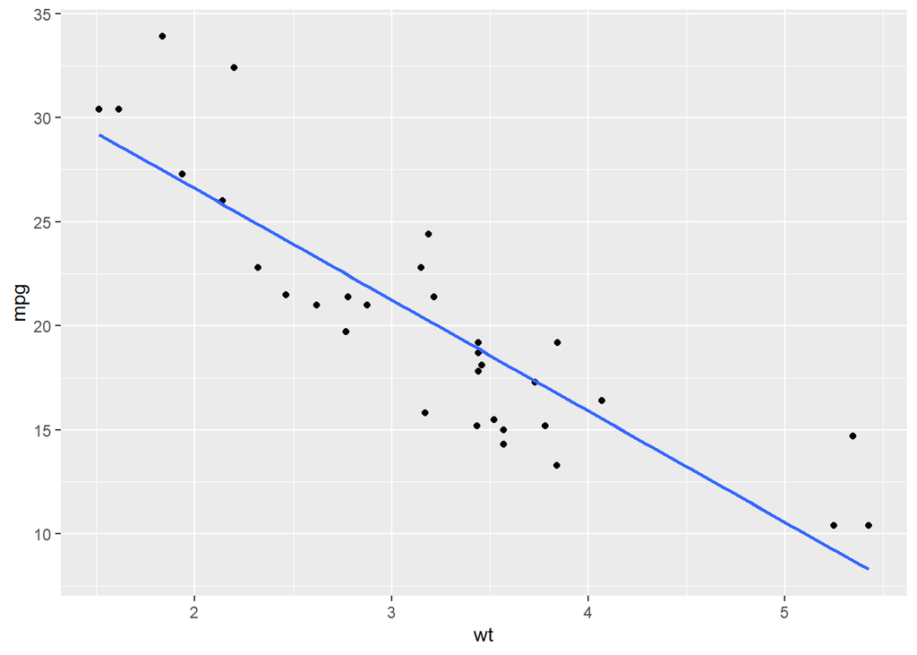

Figure 2: Data and fitted model

```r
qplot(wt,mpg,data = mtcars)+
geom_smooth(method = "lm",se = F)
```

## Parameter estimates

Parameter estimates for $S_{y}$ and $S_{x}$ are given by

```r
Sy<-sqrt(var(mtcars$mpg))
Sx<-sqrt(var(mtcars$wt))
c(Sy,Sx)
```

```
## [1] 6.0269481 0.9784574
```

The slope can be estimated by

$$\hat{\beta}_{1}=r \times \frac{Sy}{Sx}$$
,

with $r$ equal to teh corelation between $y$ and $x$. For the `mtcars` data we have

```r
cor.i<-cor(mtcars$mpg,mtcars$wt)
cor.i
```

```
## [1] -0.8676594
```

```r
beta1<-cor.i*(Sy/Sx)
beta1
```

```
## [1] -5.344472
```

Parameter estimate for the intercepet,

$$\hat{\beta}_{0}=\bar{y}-\beta_{1} \times \bar{x}$$
.

```r
mx<-mean(mtcars$wt)
my<-mean(mtcars$mpg)
c(my,mx)
```

```
## [1] 20.09062  3.21725
```

For the `mtcars` data,

```r
beta0<-my-beta1*mx
beta0
```

```
## [1] 37.28513
```

From the R output we have

```r
summary(fit.lm)$coefficients
```

```
##              Estimate Std. Error   t value     Pr(>|t|)
## (Intercept) 37.285126   1.877627 19.857575 8.241799e-19
## mtcars$wt   -5.344472   0.559101 -9.559044 1.293959e-10
```

# 3. Model diagnostic

## Checking assumptions with residual plots

The assumptions in linear regression are linearity, constant variability, independent observations, and approximate normality of residuals.

- The independence assumption has to be checked by considering study design.
- The other assumptions can be examined using *residual plots* and *normal probability plots*.
  - Residual plots: scatterplots in which predicted values are on the $x$-axis and residuals are on the $y$-axis
  - Normal probability plots: theoretical quantiles for a normal versus observed quantiles

## Checking linearity and constant variability

### Example 1

Figure~3 shows an example of resuduals for which both normality and constant variability hold.

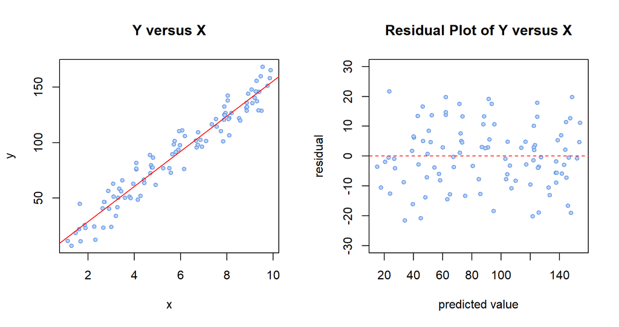

Figure 3: Example 1

### Example 2

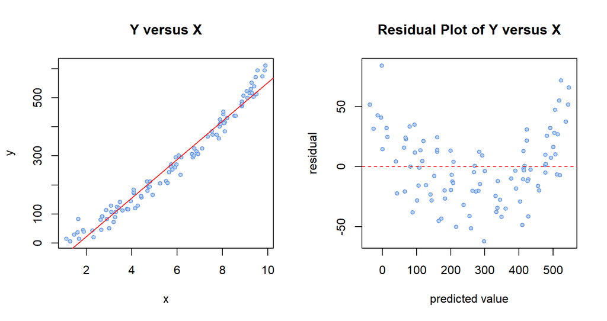

Figure 4: Example 2

## The `mtcars` dataset

For the `mtcars` data, the residuals from the model can be obtained by calling to the object `resid`, Figure 5 shows the diagnostic plots for the regression model.

```r
fit.lm$resid
```

```
##          1          2          3          4          5          6          7
## -2.2826106 -0.9197704 -2.0859521  1.2973499 -0.2001440 -0.6932545 -3.9053627
##          8          9         10         11         12         13         14
##  4.1637381  2.3499593  0.2998560 -1.1001440  0.8668731 -0.0502472 -1.8830236
##         15         16         17         18         19         20         21
##  1.1733496  2.1032876  5.9810744  6.8727113  1.7461954  6.4219792 -2.6110037
##         22         23         24         25         26         27         28
## -2.9725862 -3.7268663 -3.4623553  2.4643670  0.3564263  0.1520430  1.2010593
##         29         30         31         32
## -4.5431513 -2.7809399 -3.2053627 -1.0274952
```

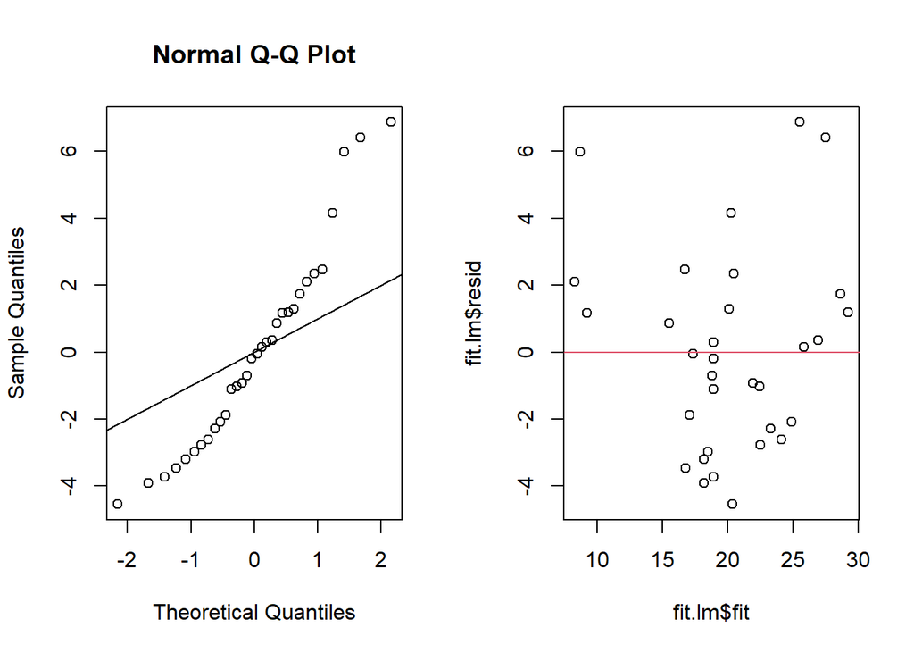

Figure 5: Diagnostic plots for the residuals

```r
par(mfrow=c(1,2))
qqnorm(fit.lm$resid)
abline(0,1)
plot(fit.lm$fit,fit.lm$resid)
abline(0,0,col=2)
```

# 4. Categorical predictors with two levels

## Simple linear regression with categorical predictor

Although the response variable in linear regression is necessarily numerical, the predictor may be either numerical or categorical. Simple linear regression only allows for categorical predictor variables with two levels while examining categorical predictors with more than two levels requires multiple linear regression. Note that fitting a simple linear regression model with a two-level categorical predictor is analogous to comparing the means of two groups, where the groups are defined by the categorical variable.

## The `mtcars` dataset

As a predictor, let us focus on the variable Transmission (the R object `am`) which takes the value of 0 if the car is automatic and 1 if the car has manual transmition. Figure 6 shows a boxplot of the mile per gallon by transmission type.

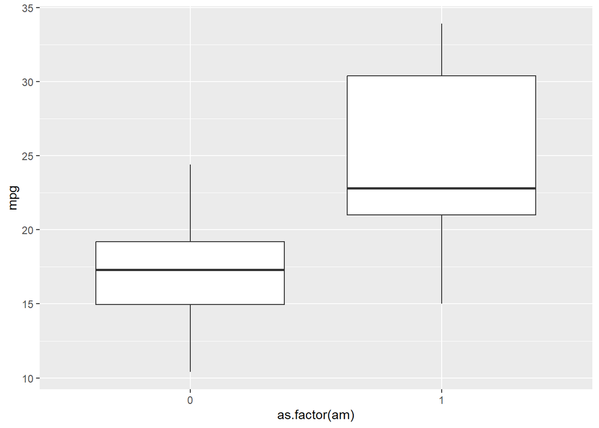

Figure 6: Boxplot plot for mpg by transmission type

```r
#boxplot(split(mtcars$mpg,mtcars$am))
ggplot(mtcars, aes(as.factor(am),mpg)) + geom_boxplot()
```

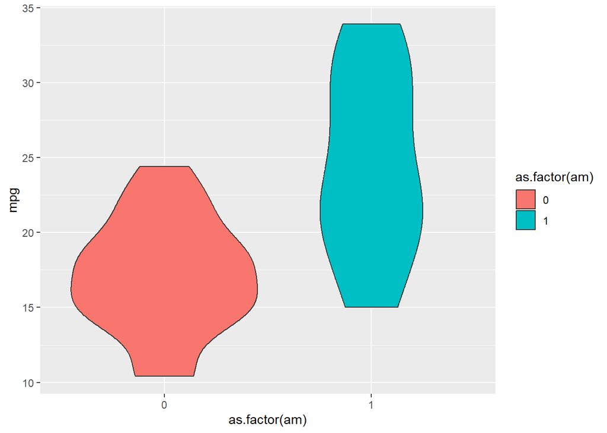

Figure 7: Violine plot for mpg by transmission type

```r
ggplot(mtcars, aes(as.factor(am),mpg)) + geom_violin(aes(fill=as.factor(am)))
```

We can see that cars with manuel transmission have, in general, higher `mpg` than cars with automatic transmission. The mean `mpg` by transmission type is given by $\bar{mpg}_{0}$ and $\bar{mpg}_{1}$,

```r
#tapply(mtcars$mpg, mtcars$am, mean)
mtcars %>% group_by(am) %>% dplyr::summarize(average = mean(mpg), standard_deviation = sd(mpg))
```

```
## # A tibble: 2 × 3
##      am average standard_deviation
##   <dbl>   <dbl>              <dbl>
## 1     0    17.1               3.83
## 2     1    24.4               6.17
```

We consider the following simple linear regression model

$$mpg_{i} = \beta_0 + \beta_1 \times am_{i} + \varepsilon_{i},$$

that can be fitted in R in the fllowing way:

```r
fit.lm2<-lm(mtcars$mpg~as.factor(mtcars$am))
summary(fit.lm2)
```

```
##
## Call:
## lm(formula = mtcars$mpg ~ as.factor(mtcars$am))
##
## Residuals:
##     Min      1Q  Median      3Q     Max
## -9.3923 -3.0923 -0.2974  3.2439  9.5077
##
## Coefficients:
##                       Estimate Std. Error t value Pr(>|t|)
## (Intercept)             17.147      1.125  15.247 1.13e-15 ***
## as.factor(mtcars$am)1    7.245      1.764   4.106 0.000285 ***
## ---
## Signif. codes:  0 '***' 0.001 '**' 0.01 '*' 0.05 '.' 0.1 ' ' 1
##
## Residual standard error: 4.902 on 30 degrees of freedom
## Multiple R-squared:  0.3598, Adjusted R-squared:  0.3385
## F-statistic: 16.86 on 1 and 30 DF,  p-value: 0.000285
```

# 5. Goodness of fit: using $R^2$ to describe the strength of a fit

## The quantity $R^2$

The correlation coefficient $r$ measures the strength of the linear relationship between two variables. It is more common to use $r^2$ to measure the strength of a linear fit, which is written as $R^2$ in the context of regression. $R^2$ describes the amount of variation in the response that is explained by the least squares line.
$$R^{2} = \dfrac{\text{variance of predicted $y$-values}}{\text{variance of observed $y$-values}} = \dfrac{\text{Var}(\hat{y}_i)}{\text{Var}(y_i)}.$$

If a linear model perfectly captured the variability in the observed data, then $\text{Var}(\hat{y}_i)$ would equal $\text{Var}(y_i)$ and $R^2$ would be 1.

## The quantity $R^2$

$R^2$ can also be calculated using the following formula:

$$R^{2} = \dfrac{\text{variance of observed $y$-values} - \text{variance of residuals}}{\text{variance of observed $y$-values}} = \dfrac{\text{Var}(y_i) - \text{Var}(e_i)}{\text{Var}(y_i)}$$

The variability of the residuals about the line represents the remaining variability after the model is fit. In other words, $\text{Var}(e_i)$ is the variability unexplained by the model and $R^{2}$ is the proportion of variability explained by the model.

## The `mtcars` dataset

Let us look again in the output of the linear regression model in which the car’s weight is the predictor.

```r
summary(fit.lm)
```

```
##
## Call:
## lm(formula = mtcars$mpg ~ mtcars$wt)
##
## Residuals:
##     Min      1Q  Median      3Q     Max
## -4.5432 -2.3647 -0.1252  1.4096  6.8727
##
## Coefficients:
##             Estimate Std. Error t value Pr(>|t|)
## (Intercept)  37.2851     1.8776  19.858  < 2e-16 ***
## mtcars$wt    -5.3445     0.5591  -9.559 1.29e-10 ***
## ---
## Signif. codes:  0 '***' 0.001 '**' 0.01 '*' 0.05 '.' 0.1 ' ' 1
##
## Residual standard error: 3.046 on 30 degrees of freedom
## Multiple R-squared:  0.7528, Adjusted R-squared:  0.7446
## F-statistic: 91.38 on 1 and 30 DF,  p-value: 1.294e-10
```

The Adjusted $R^{2}$ (to the intercept in teh model) is equal to 0.7446 which implies that the regression model explains approximatly $75\%$ of the total variability of the response.

# 6. Statistical inference in regression

## The model for statistical inference

The observed data $(x_i, y_i)$ are assumed to have been randomly sampled from a population where the explanatory variable $X$ and the response variable $Y$ follow a population model
$$Y = \beta_0 + \beta_1X + \epsilon,$$
where $\epsilon \sim N(0, \sigma)$. Under this assumption, the slope and intercept of the regression line, $b_0$ and $b_1$, are estimates of the population parameters $\beta_0$ and $\beta_1$.

## Hypothesis testing in regression

Inference in a regression context is usually about the slope parameter, $\beta_1$.

The null hypothesis is most commonly a hypothesis of ‘no association’:

- $H_0: \beta_1 = 0$, the $X$ and $Y$ variables are not associated
- $H_A: \beta_1 \neq 0$, the $X$ and $Y$ variables are associated

The $t$-statistic has degrees of freedom $n - 2$, where $n$ is the number of ordered pairs in the dataset.
$$t = \dfrac{b_1 - \beta_1^0}{\text{s.e.}(b_1)} = \dfrac{b_1}{\text{s.e.}(b_1)}$$

The value $\beta_1^0$ equals 0 when the null hypothesis is one of no association.

### The `mtcars` dataset

```r
summary(fit.lm)$coefficients
```

```
##              Estimate Std. Error   t value     Pr(>|t|)
## (Intercept) 37.285126   1.877627 19.857575 8.241799e-19
## mtcars$wt   -5.344472   0.559101 -9.559044 1.293959e-10
```

## Confidence intervals in regression

A 95% confidence interval for $\beta_1$ has the following formula
$$b_1 \pm \left( t^\star \times \text{s.e.}(b_1) \right),$$

where $t^\star$ is the point on a $t$-distribution with $n - 2$ degrees of freedom and $\alpha/2$ area to the right.

### The `mtcars` dataset

For the `mtcars` data we have

$$b_1 \pm \left( t^\star \times \text{s.e.}(b_1) \right)=-5.34 \pm \left( t^\star \times 0.559 \right)$$
,

```r
qt(0.975,30)
```

```
## [1] 2.042272
```

A $95\%$ C.I for $\beta_{1}$ is given by

```r
UL<- -5.34+2.042*0.55
LL<- -5.34-2.042*0.55
c(LL,UL)
```

```
## [1] -6.4631 -4.2169
```